# Lab 11: Factorial ANOVA

ENVS475: Experimental Analysis and Design

Spring, 2023

# About

This lab will demonstrate how to perform a two-way ANOVA’s (without interaction) in R. This includes checking assumptions, fitting the linear model, interpreting and visualizing the results.

# Preliminaries

### Packages

For this lab, we will be using the `dplyr` and `ggplot2` packages. Make sure both packages are installed on your computer, and then run the following code:

```r
library(dplyr)
library(ggplot2)
```

### Data

We will use the `crop_anova.csv` data which can be downloaded on D2L. Load the data by running the following command:

```r
crop <- read.csv("data/crop_anova.csv")
```

# Analysis

In the previous homework, we analyzed a subset of the data and looked for significant differences in the yield based on fertilizer type. This time, we will keep both the plant density the fertilizer treatment to run a factorial analysis. We will just be looking at the main effects, and will hold off on the potential interaction effect until a future class.

Let’s look at the full data, and see what the treatment levels are.

```r
names(crop)
```

```
## [1] "density"    "block"      "fertilizer" "yield"
```

```r
dim(crop)
```

```
## [1] 96  4
```

```r
head(crop)
```

```
##   density block fertilizer    yield
## 1     low     I    control 177.2287
## 2     low     I    control 177.1255
## 3     low     I    control 176.2749
## 4     low     I    control 177.4795
## 5     low     I    control 176.1083
## 6     low     I    control 176.2390
```

```r
distinct(crop, density)
```

```
##   density
## 1     low
## 2    high
```

```r
distinct(crop, fertilizer)
```

```
##   fertilizer
## 1    control
## 2          N
## 3          P
```

We can also use the `tab()` function to see how many observations are in each group:

```r
table(crop$density, crop$fertilizer)
```

```
##
##        control  N  P
##   high      16 16 16
##   low       16 16 16
```

We can see that there are 16 observations in each combination of all levels for both factors. We call this a completely balanced ANOVA design.

## Plot data

Let’s start by plotting all of the data. We will save time and consider all the grouping variables.

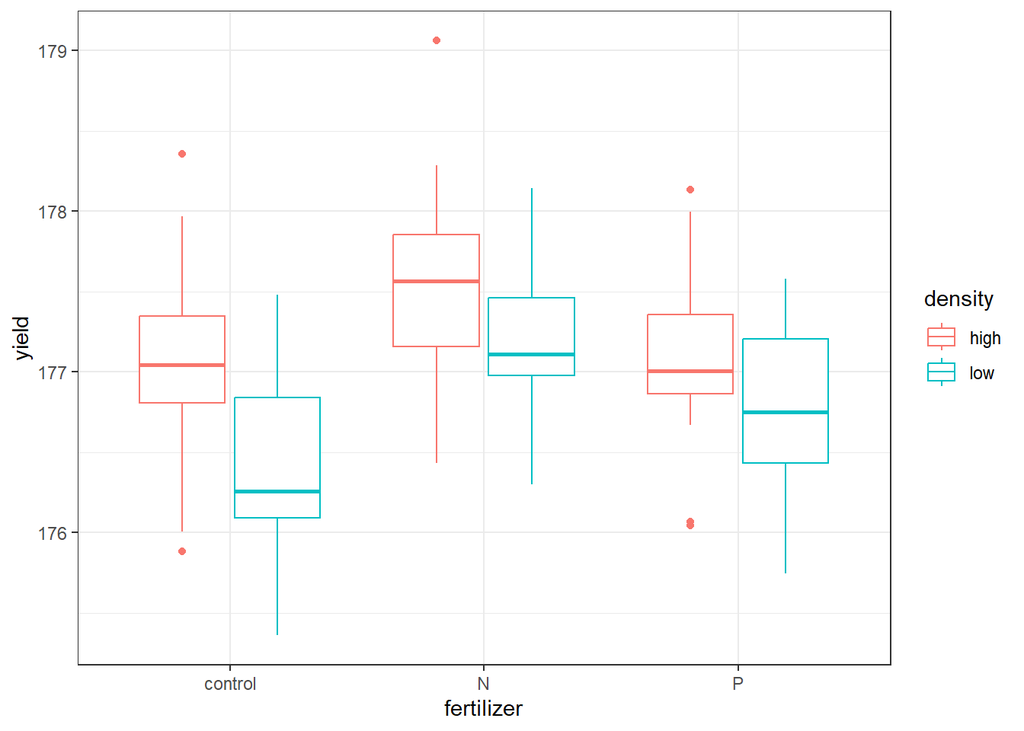

```r
ggplot(crop,
       aes(x = fertilizer,
           y = yield,
           color = density)) +
  geom_boxplot() +
  theme_bw()
```

If you wanted to get a visual indication of the main effects, you could plot the grouping variables one at a time.

- i.e., set both the `x` and `color` variable above to `fertilizer` for one plot, and then change them both to `density` for the second plot.

## Check pre-analysis assumptions

### Assumption: equal variance

These data look to have approximately equal variation across the treatment groups. The *“low-N”*, and *“high-P”* groups look a little more narrow, but this shouldn’t be an issue.

### Assumptions: Normality of residuals

We can also check to see if the residuals are normally ditributed by creating a QQ-plot.

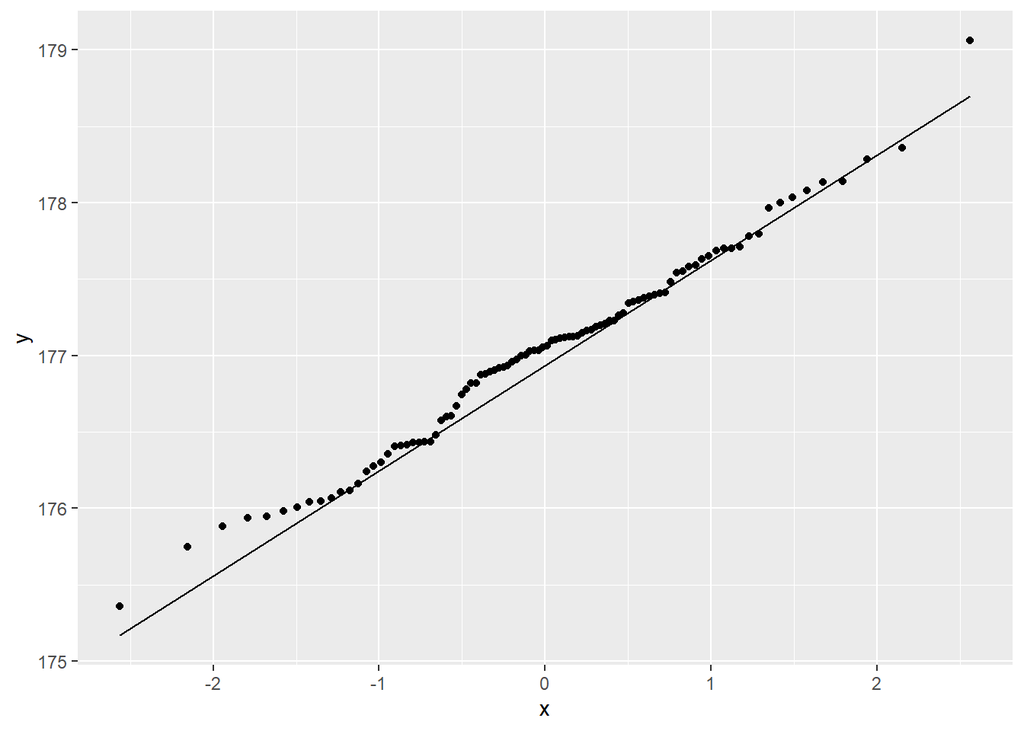

```r
ggplot(crop,
       aes(sample = yield)) +
  stat_qq()+
  stat_qq_line()
```

Most of the observations (points) fall close to the reference line. There’s a few that are off near the low end of the data, but this should be ok.

# Factorial ANOVA

## Hypotheses for main effects

In a factorial ANOVA analysis (without interactions), we have a number of main hypotheses equal to the number of factors in our design. In this case, we have the **density** and the **fertilizer** factor, so our hypotheses are:

### Density main effect hypotheses

$$H0: \mu_{low} = \mu_{high}$$

$$HA: \text{At least one mean is
different}$$

### Fertilizer main effect hypotheses

Null and alternative hypotheses:

$$H0: \mu_{control} = \mu_{N} =
\mu_{P}$$

$$HA: \text{At least one mean is
different}$$

We will discuss the null and alternative hypotheses for the interaction later.

## ANOVA with `lm()`

### Assumption: Equal variance of residuals

Let’s first fit a linear model to the data, and check our post-model fit assumption with a fitted vs. residuals plot.

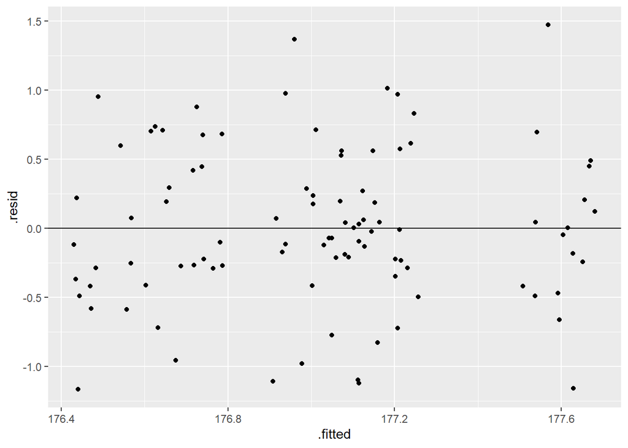

```r
crop_lm <- lm(yield ~ density + fertilizer, data = crop)
ggplot(crop_lm,
       aes(x = .fitted, y = .resid)) +
    geom_point(
      position = position_jitter(
        width = 0.1,
        height = 0)) +
    geom_hline(yintercept = 0)
```

# ANOVA table

In order to get the statistical values for the ANOVA table, we need to use the `anova()` function on the model fit object.

```r
anova(crop_lm)
```

```
## Analysis of Variance Table
##
## Response: yield
##            Df  Sum Sq Mean Sq F value    Pr(>F)
## density     1  5.1217  5.1217 15.3162 0.0001741 ***
## fertilizer  2  6.0680  3.0340  9.0731 0.0002533 ***
## Residuals  92 30.7645  0.3344
## ---
## Signif. codes:  0 '***' 0.001 '**' 0.01 '*' 0.05 '.' 0.1 ' ' 1
```

You can see that we know have a row for each of the main factors (density, fertilizer) as well as a third row for the residuals (unexplained variation).

We interpret the F-value for each factor as before, but in this case, we can say that these are the *main effects* of that factor, while accounting for the variation in the other factor.

The p-value is an indication of the likelihood of observing the data (i.e., F-value, signal / noise ratio) we have *if* the null hypothesis was true. In this case, both p-values are < 0.002 which is less than $\alpha = 0.05$, and we can conclude that there is a significant main effect for each factor.

## PLotting main effects separately

It can be helpful to plot the data considering only one factor at a time to see the main effects.

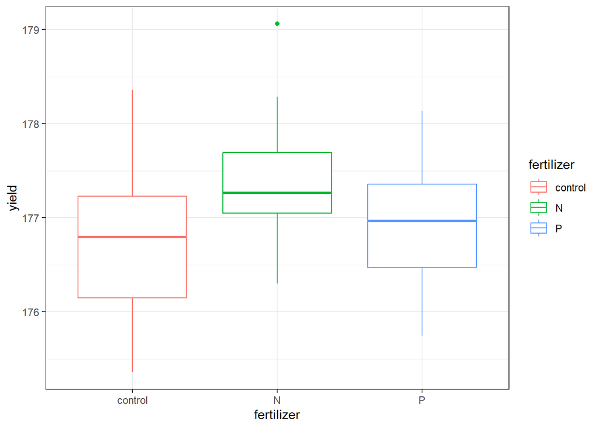

```r
ggplot(crop,
       aes(x = fertilizer,
           y = yield,
           color = fertilizer)) +
  geom_boxplot() +
  theme_bw()
```

This plot shows the average yield based on fertilizer type, **ignoring the effect** of the density factor.

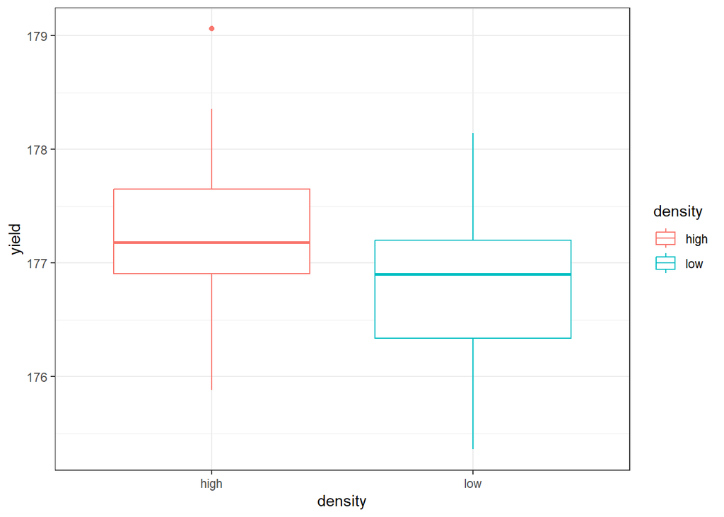

```r
ggplot(crop,
       aes(x = density,
           y = yield,
           color = density)) +
  geom_boxplot() +
  theme_bw()
```

This plot shows the average yield based on density type, **ignoring the effect** of the fertilizer factor.

## ANOVA Interpretation

Remember that the hypotheses for ANOVA are either that all means are the same, or that at least one was different. ANOVA can only tell us that there is a difference. Therefore, out interpretation would look something like this:

> Based on a 2-way ANOVA (no interaction), there were significant main effects of planting density ($F_{1, 92}= 15.31, p < 0.001$) and fertilizer addition ($F_{2, 92}= 9.07, p < 0.001$).

In order to see *which* means are different, we can view the summary output from the `lm()` model as we did before. In this lab, I’m going to jump straight into the post-hoc Tukey HSD test.

# Multiple Comparisons

## Tukey’s HSD

As mentioned above, the results of the ANOVA test indicated significant differences. As researchers, we most likely want to know *which* groups are different. For example, telling farmers that density anf fertilizer are important isn’t overly helpful. Telling them which fertilizer to use and which density to maximize their yield would be helpful.

Before we run the Tukey HSD test, we need to run an ANOVA on our linear model fit using the `aov()` function.

```r
# ANOVA of our lm model
crop_aov <- aov(crop_lm)

# Tukey's test on the plant_aov object
crop_tukey <- TukeyHSD(crop_aov)
# print out results
crop_tukey
```

```
##   Tukey multiple comparisons of means
##     95% family-wise confidence level
##
## Fit: aov(formula = crop_lm)
##
## $density
##               diff        lwr        upr     p adj
## low-high -0.461956 -0.6963916 -0.2275205 0.0001741
##
## $fertilizer
##                 diff        lwr         upr     p adj
## N-control  0.5991256  0.2547318  0.94351936 0.0002219
## P-control  0.1761687 -0.1682251  0.52056252 0.4452958
## P-N       -0.4229568 -0.7673506 -0.07856306 0.0119381
```

Here, we can see that we have a section for each factor, and a row for every pairwise combination. The table gives us an estimated and 95% CI for the differences, as well as an adjusted p value.

## Tukey HSD Interpretation

### Fertilizer

There was no significant change in yield with the addition of Phosphorous fertilizer (95% CI of estimates change: -0.17, 0.52). However, the addition of Nitrogen increased yield compared with no fertilizer by 0.60 (95%CI 0.25, 0.94) kg, and the yield for N was 0.422 (95%: 0.77, 0.08) kg greater than with Phosphorous fertilizer, and both of these differences were significant (adjusted p-values = <0.001 and 0.012, respectively).

**NOTE** that I switched the sign on the P-N comparison to fit the narrative. This makes the comparison N-P.

We can also plot these differences. Any coefficient estimates which cross zero are not considered to be significantly different.

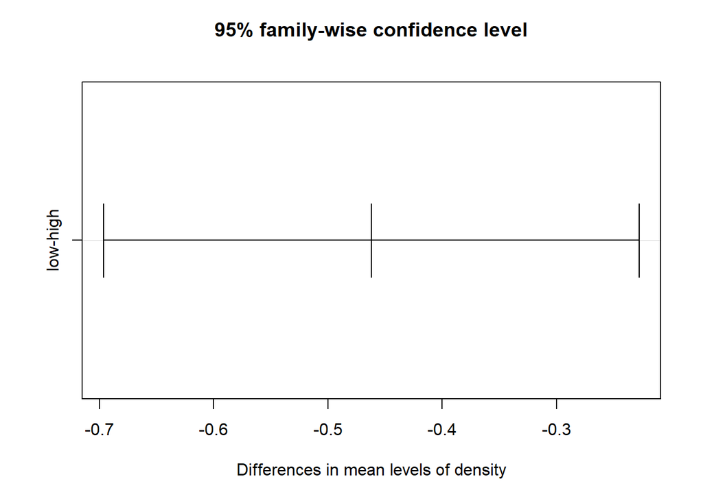

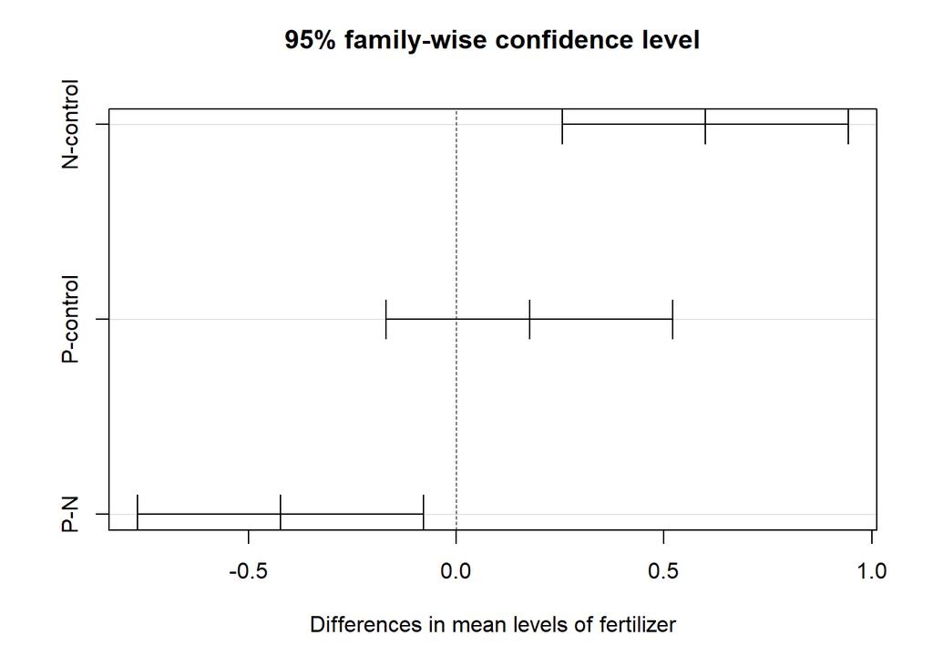

```r
plot(crop_tukey)
```

# Blocking

The `crop_anova` data also includes a blocking variable. We can include this in our analysis by adding it as a factor to our `lm()` formula. I will not go through the full process of plotting the data and checking the assumptions here, but for a formal analysis you should do it again including all of the grouping variables.

I’m not familiar with the original design of this experiment, but presumably the different blocks were fields when the different treatments were randomly assigned.

## Blocking factor in `lm()`

```r
crop_block_lm <- lm(yield ~ density + fertilizer + block, data = crop)

anova(crop_block_lm)
```

```
## Analysis of Variance Table
##
## Response: yield
##            Df  Sum Sq Mean Sq F value    Pr(>F)
## density     1  5.1217  5.1217 15.2238 0.0001840 ***
## fertilizer  2  6.0680  3.0340  9.0184 0.0002693 ***
## block       2  0.4861  0.2431  0.7225 0.4883291
## Residuals  90 30.2784  0.3364
## ---
## Signif. codes:  0 '***' 0.001 '**' 0.01 '*' 0.05 '.' 0.1 ' ' 1
```

Here, we can see that the blocking factor was not significant. In other words, there was not a high degree of variation associated with the individual block.

You can then continue the analysis by looking at the coefficient estimates from the `lm()` model, as well as perform post-hoc multiple comparisons, but I will skip that in this lab.

Note that the residual_{df}, F-values, and p-values all changed slightly with the addition of a blocking factor. Opinions differ on how to proceed with a non-significant blocking variable. Some say that since it’s not significant you can drop it and re-run the analysis without it (i.e., the analysis at the beginning of this lab). Dropping the block will increase your degrees of freedom and can give you slightly more statistical power.

Other people say that you had the block in the original design and it’s disingenuous throw it out now, and you should keep it in the analysis and report the lack of significance.

This discussion foreshadows a more complex philosophical as well as technical concept of model selection. We most likely won’t have time to dive into that topic in this class, but just know that there are entire books written on when, how, and where to perform model selection. Luckily, much of this information is also online, so if and when you find yourself in that situation there are plenty of resources available for you to dive in. (Or, more realistically, your boss / adviser / etc. will probably have an opinion or a preferred method, so you will do that for a while until you get more experience and then one day you’ll get interested in it and go down a Wikipedia rabbit hole and come out the other side having ordered multiple books online which you will probably never fully read, but will still come to your own preferred method through a combination of trial-and-error, discussions with colleagues, and divination. Not that I’m speaking from personal experience or anything…)

### You should now be able to complete part of the homework. I’ll know more once I actually write it.

# Complex blocking designs: the Latin Square

The Latin Square is a specific design which uses two blocking factors to control for variation. The `OrchardSprays` data we worked with previously was a Latin Square design. We can recreate this design visually using the `matrix()` function.

```r
data("OrchardSprays")
head(OrchardSprays)
```

```
##   decrease rowpos colpos treatment
## 1       57      1      1         D
## 2       95      2      1         E
## 3        8      3      1         B
## 4       69      4      1         H
## 5       92      5      1         G
## 6       90      6      1         F
```

```r
matrix(OrchardSprays$treatment, 8, 8)
```

```
##      [,1] [,2] [,3] [,4] [,5] [,6] [,7] [,8]
## [1,] "D"  "C"  "F"  "H"  "E"  "A"  "B"  "G"
## [2,] "E"  "B"  "H"  "A"  "D"  "C"  "G"  "F"
## [3,] "B"  "H"  "A"  "E"  "G"  "F"  "C"  "D"
## [4,] "H"  "D"  "E"  "C"  "A"  "G"  "F"  "B"
## [5,] "G"  "E"  "D"  "F"  "C"  "B"  "A"  "H"
## [6,] "F"  "A"  "C"  "G"  "B"  "D"  "H"  "E"
## [7,] "C"  "F"  "G"  "B"  "H"  "E"  "D"  "A"
## [8,] "A"  "G"  "B"  "D"  "F"  "H"  "E"  "C"
```

We can see that each row and column has the letters A-H in it exactly once. In this instance, the design was to control for variability in space (N-S, E-W) across a large agricultural field setting, but the rows and columns could also be specific treatment levels.

For example, in the homework data set, each row is a different fertilizer treatment, each column is a different tillage treatment, and then each unique position of row and column is a different seed variety.

```
##         treatA treatB treatC treatD treatE
## fertil1 "A"    "C"    "B"    "D"    "E"
## fertil2 "E"    "B"    "C"    "A"    "D"
## fertil3 "C"    "A"    "D"    "E"    "B"
## fertil4 "B"    "D"    "E"    "C"    "A"
## fertil5 "D"    "E"    "A"    "B"    "C"
```

## Data wrangling

### Change blocking variables to `factors`

You may have noticed that the row and column position variable is described with a number, and R will interpret this as a continuous variable:

```r
class(OrchardSprays$rowpos)
```

```
## [1] "numeric"
```

We want R to treat these blocking variables as different groups (called factors in R-speak), not as a continuous variable. To do that, we can use our old friend `mutate`. In the following code, we will make new variables for `rowpos` and `colpos`, and add `_f` to the end of the name to indicate that they are now “factors”.

```r
os <- OrchardSprays %>%
  mutate(rowpos_f = factor(rowpos),
         colpos_f = factor(colpos))
head(os)
```

```
##   decrease rowpos colpos treatment rowpos_f colpos_f
## 1       57      1      1         D        1        1
## 2       95      2      1         E        2        1
## 3        8      3      1         B        3        1
## 4       69      4      1         H        4        1
## 5       92      5      1         G        5        1
## 6       90      6      1         F        6        1
```

This is a good opportunity to remind you all to think about how you’re going to analyze your data *before* you enter it. If you know your going to be running an ANOVA or some other type of categorical analysis, enter row position as “r1” instead of 1. Likewise, column position 2 could be “c2”. This way, when you load your data into R, it automatically treats it as a categorical variable, and then you don’t have to mess around with changing the class of the variable. (It will also prevent you from running a full analysis, interpreting the results and writing it up, only to find out that your blocking variables are continuous instead of categorical. This is exactly what just happened to me as I was writing this lab exercise.)

### Transform response variable

#### Skip this in week 11

You may recall from the homework that the `OrchardSprays` data failed its assumption checks. There are a few options for you to do when this occurs. I’m hoping to go through them in more detail later, but for now, suffice it to say that we can transform the variable to see if that fixes our problems. A common transformation is a log-transformation.

### Log transformation

The following code takes the natural logarithm (`log()`) of the response variable, `decrease` and saves it in a new variable.

```r
os_transform <- os %>%
  mutate(l_decrease = log(decrease +1))
head(os_transform)
```

```
##   decrease rowpos colpos treatment rowpos_f colpos_f l_decrease
## 1       57      1      1         D        1        1   4.060443
## 2       95      2      1         E        2        1   4.564348
## 3        8      3      1         B        3        1   2.197225
## 4       69      4      1         H        4        1   4.248495
## 5       92      5      1         G        5        1   4.532599
## 6       90      6      1         F        6        1   4.510860
```

Let’s quickly check the assumptions again to see if this transformation fixed the problems.

### Grouped-box plots: Normal variance

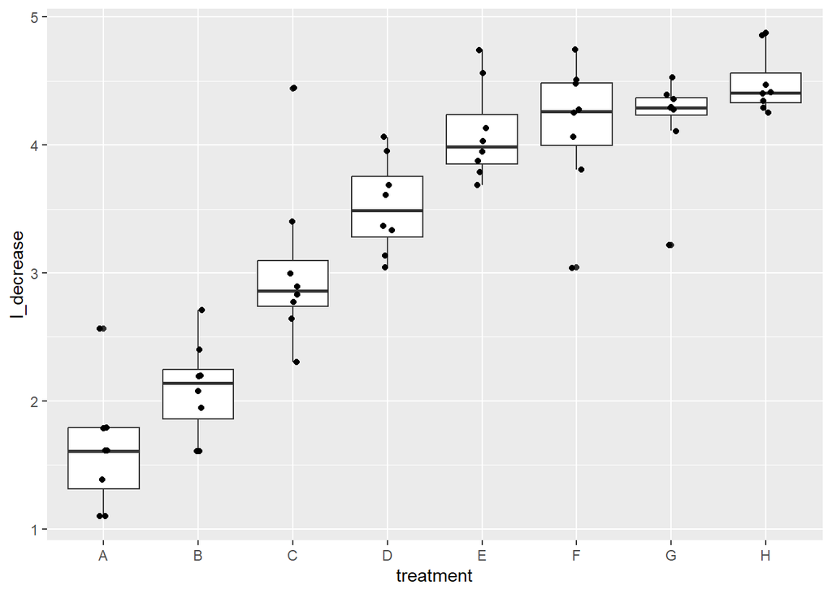

```r
ggplot(os_transform,
       aes(x = treatment,
           y = l_decrease))+
  geom_boxplot() +
  geom_point(position = position_jitter(
    width = 0.05
  ))
```

Variance between groups looks much more equal the “G” group is a little small, but looks much better than before.

### QQplot: Normality of residuals

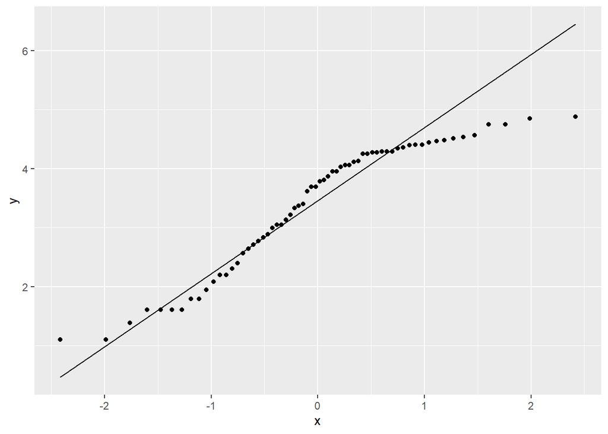

```r
ggplot(os_transform, aes(sample = l_decrease)) +
  stat_qq() + # plot qq points
  stat_qq_line() # reference line
```

This still doesn’t look ideal, but linear model analyses are fairly robust to this assumption, so it’s probably OK.

### Fit the model

In the modified `os` data, the blocking factors are indicated by the `rowpos_f` and `colpos_f` variables. The level of pesticide is indicated by the `treatment` level, and the transformed response variable is the `l_decrease` variable (measuring the decline in bee numbers). We can incorporate this into an `lm()` analysis by adding more predictor variables.

```r
os_lm <- lm(l_decrease ~ treatment + rowpos_f + colpos_f, data = os_transform)
```

### Fitted Vs. Redisual: Equal variance of residuals

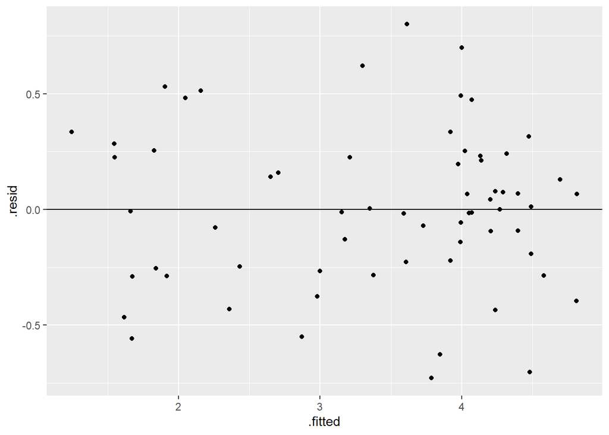

```r
ggplot(os_lm,
       aes(x = .fitted, y = .resid)) +
  geom_point(
    position = position_jitter(
      width = 0.05)) +
  geom_hline(yintercept = 0)
```

Once again, not perfect, but looks much better than it did before.

### Continuing the analysis

Now, we can run the same analysis as normal, but we will use the new data object `os_transform` and the new variable `l_decrease` in our function calls.

## ANOVA with two blocking factors

For this analysis, we have three factors, each of which has 2 or more levels:

- treatment factor: Levels A-H.
- Row position factor: Levels 1-8
- Col position factor: Levels 1-8

```r
anova(os_lm)
```

```
## Analysis of Variance Table
##
## Response: l_decrease
##           Df Sum Sq Mean Sq F value  Pr(>F)
## treatment  7 62.904  8.9862 51.5196 < 2e-16 ***
## rowpos_f   7  2.768  0.3955  2.2672 0.04726 *
## colpos_f   7  0.850  0.1214  0.6960 0.67498
## Residuals 42  7.326  0.1744
## ---
## Signif. codes:  0 '***' 0.001 '**' 0.01 '*' 0.05 '.' 0.1 ' ' 1
```

Here, we find that there was a significant main effect of treatment ($F_{7, 42} = 51.52, p < 0.001$). This means that the decrease in bees did change based on herbicide treatment level.

We also found a significant main effect of row position ($F_{7, 42} = 2.27, p < 0.05$). This means that the decrease in bees did change just based on the row that the data was collected in. In other words, the number of bees varied across the experimental field *independent of the treatments*.

It’s worth noting that despite this finding, the effect of treatment was still noticeable, and the results reported above are accounting for the differences in row position. Another way of saying this is that the effect of treatment was significant *while controlling for the effect of row position*.

As an example, we can run the analysis without the `rowpos_f` variable.

```r
os_lm_2 <- lm(l_decrease ~ treatment +  colpos_f, data = os_transform)
anova(os_lm_2)
```

```
## Analysis of Variance Table
##
## Response: l_decrease
##           Df Sum Sq Mean Sq F value Pr(>F)
## treatment  7 62.904  8.9862 43.6227 <2e-16 ***
## colpos_f   7  0.850  0.1214  0.5893 0.7613
## Residuals 49 10.094  0.2060
## ---
## Signif. codes:  0 '***' 0.001 '**' 0.01 '*' 0.05 '.' 0.1 ' ' 1
```

The overall conclusions from our second model did not change. However, if you look closely at the output of our second model, you will notice that the F-value is *lower* in the second model, even though we have more degrees of freedom (and hence, more statistical power) since we have one fewer predictor variables. In this case, the F-value is still so high that our results are highly significant, but this lower F-value means that we are explaining less of the variation in the data.

Another way of showing this is the adjusted R<sup>2</sup> value from out `lm()` output.

```r
# full model, with rowpos_f blocking
summary(os_lm)$adj.r.square
```

```
## [1] 0.8511974
```

```r
# second model, without rowpos_F blocking
summary(os_lm_2)$adj.r.square
```

```
## [1] 0.82426
```

Again, the differences here are not striking and the overall conclusions are the same. However, the second model explains less of the variation, indicated by a lower Adjusted R<sup>2</sup> value. Including the `rowpos_F` block in the analysis explains more of the variation than ignoring it.

There are situations where including a grouping variable can explain enough of the variation that the main effect of other factors goes from insignificant to significant (this might happen in your homework, *wink wink*).

Again, this brings up interesting questions about model selection, which we will leave unanswered for the time being.

### Coda

This concludes Lab 11, and you should now be able to complete the homework assignment.